# Table of Contents

## Conformal Mapping

```python
import numpy as np
import matplotlib.pyplot as plt
```

By definition a **conformal mapping** $w(z)$ is an angle preserving function. Conformal mappings can be used to visualize complex functions in different geometries.

### Corner Flow

[figure not shown]

```python
# Potential Flow in a corner of angle pi*alpha
fig, ax = plt.subplots(figsize=(4,4))
xmin = -2; xmax = 2; ymin = 0; ymax = 2; alpha = 1/3; Q0 = 1+0j;

dx = (xmax-xmin)/100; dy = (ymax-ymin)/100;
x = np.arange(xmin,xmax,dx); y = np.arange(ymin,ymax,dy);
[X,Y] = np.meshgrid (x,y)                           # mesh in z-plane
Z = X+1j*Y
Phi =  -np.conj(Q0)*Z                               # baseflow
W = Z**alpha                                        # mesh in w-plane
X = np.real(W); Y = np.imag(W)

plt.contourf (X,Y,np.real(Phi),40,cmap='RdBu')
cnt1 = plt.contour (X,Y,np.real(Phi),40,colors='k')
h1,_ = cnt1.legend_elements()
h2,_ = cnt2.legend_elements()
plt.legend = ax.legend([h1[0],h2[0]],['potential','streamlines'],frameon = True,facecolor='lightgray',fontsize=12, loc=2)
plt.xlim (0,1); plt.ylim (0,1)
ax.set_title('Corner Flow 60$^{\circ}$')
plt.show()
```

After defining uniform flow in the $z$-plane, the coordinates are transferred to the $w$-plane for visualization. Note that the final mesh is created in the $w$-plane. In order to obtain the flow field in a square the graphic limits have to be modified, as performed in the last command.

The following demonstrates an alternative meshing procedure. Here the mesh is defined in the $w$-plane and in polar coordinates. In the demonstration we choose $\alpha=2/3$ for a change.

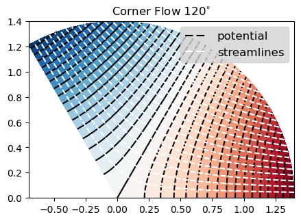

```python
# Potential Flow in a corner of angle pi*alpha
fig, ax = plt.subplots(figsize=(5, 5))
L = 1.4; alpha = 2/3; Q0 = 10+0j

r = np.linspace(0,L,50); ang = np.linspace(0,np.pi*alpha,25)
[R,Ang] = np.meshgrid (r,ang)
W = R*np.exp(1j*Ang)                                          # mesh in w-plane in polar coordinates
X = np.real(W); Y = np.imag(W)
Z = W**(1/alpha)                                              # mesh in z-plane
Phi = -np.conj(Q0)*Z                                          # complex potential

plt.contourf (X,Y,np.real(Phi),40,cmap='RdBu')
cnt1 = plt.contour (X,Y,np.real(Phi),40,colors='k')
h1,_ = cnt1.legend_elements()
cnt2 = plt.contour (X,Y,np.imag(Phi),20,colors='white')
h2,_ = cnt2.legend_elements()
plt.legend = ax.legend([h1[0],h2[0]],['potential','streamlines'],frameon = True,facecolor='lightgray',fontsize=12, loc=1)
ax.set_title('Corner Flow 120$^{\circ}$')
ax.set_aspect('equal')
plt.show()
```

### Flow around a Sharp Corner

**Task 1**: Change the program above to model flow around a sharp corner!

[figure not shown]

```python
L = 1.4; alpha = 2; Q0 = 1+0j

r = np.linspace(0,L,200); ang = np.linspace(0,np.pi*alpha,200)
[R,Ang] = np.meshgrid (r,ang)
W = R*np.exp(1j*Ang)                                         # mesh in w-plane in polar coordinates
X = np.real(W); Y = np.imag(W)
Z = W**(1/alpha)                                             # mesh in z-plane
Phi = -np.conj(Q0)*Z                                         # complex potential

fig, ax = plt.subplots(figsize=(5, 5))
plt.contourf (X,Y,np.real(Phi),40,cmap='RdBu')
cnt1 = plt.contour (X,Y,np.real(Phi),40,colors='k')
h1,_ = cnt1.legend_elements()
cnt2 = plt.contour (X,Y,np.imag(Phi),20,colors='white')
h2,_ = cnt2.legend_elements()
plt.legend = ax.legend([h1[0],h2[0]],['potential','streamlines'],frameon = True,facecolor='lightgray',fontsize=12, loc=1)
ax.set_title('Corner Flow 135$^{\circ}$')
ax.set_aspect('equal')
plt.show()
```

Note that $z$=0 is a singular point.

According to the differentian rules the velocity is given by $ \pmb{v} = -1/(2 \sqrt{z}) $.

**Task 2**: Modify the plot to visualize the logarithm of velocity by the colors! Add colormap!

[figure not shown]

```python
L = 1.4; alpha = 2; Q0 = 1+0j

r = np.linspace(0.01,L,200); ang = np.linspace(0.01,np.pi*alpha,200)
[R,Ang] = np.meshgrid (r,ang)
W = R*np.exp(1j*Ang)                                  # mesh in w-plane in polar coordinates
X = np.real(W); Y = np.imag(W)
Z = W**(1/alpha)                                      # mesh in z-plane
Phi = -np.conj(Q0)*Z                                  # complex potential

fig, ax = plt.subplots(figsize=(6, 6))
plt.contourf (X,Y,np.log(np.abs(-0.5/Z)),40,cmap='coolwarm')
plt.colorbar()
cnt1 = plt.contour (X,Y,np.real(Phi),40,colors='k')
h1,_ = cnt1.legend_elements()
cnt2 = plt.contour (X,Y,np.imag(Phi),20,colors='white')
h2,_ = cnt2.legend_elements()
plt.legend = ax.legend([h1[0],h2[0]],['potential','streamlines'],frameon = True,facecolor='lightgray',fontsize=12, loc=1)
ax.set_title('Corner Flow 135$^{\circ}$')
ax.set_aspect('equal')
plt.show()
```

### Flow over a Cylinder

Here we are dealing with the flow past an onstacle with cylindrical cross-section. For this we make use of the **Milne-Thomson** circle theorem. It states: If $\Omega$ is a solution in the entire complex domain with all its singularities outside of the sphere $\lvert z\rvert < r_0$, then the function

\begin{equation} \Phi(z) = \Omega(z)+\overline{\Omega}(r_0^2/\overline{z}) \end{equation}

is a complex potential defined in the plane without the sphere $\lvert z\rvert \le r_0$, a streamline at the circle $\lvert z\rvert = r_0$ and the same singularies. The overline denotes the conjugate complex.

For the proof see for example: Orloff (2024). For the illustration let's start with uniform flow in the complex plane. The mentioned map transforms the plane to a domain without the sphere. A flow pattern results that shows how a fluid entering from the side circumvents the cylinder. By puting a black circle in the center ('add_patch' command) we block out the visualization of the interior of the sphere, which is irrelevant for the flow pattern in question.

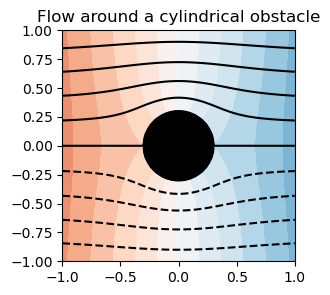

```python
fig, ax = plt.subplots(figsize=(3,3))
Q0 = 0.5                                    # uniform flow
r0 = 0.3                                    # cylinder radius
xmin = -1.; xmax = 1.                       # x-axis plot window
ymin = -1.; ymax = 1.                       # y-axis plot window

x = np.linspace(xmin,xmax,50); y = np.linspace(ymin,ymax,50)
X,Y = np.meshgrid (x,y); Z = X + 1.j*Y      # complex mesh
Phi = Q0*Z + np.conj(Q0*r0*r0/np.conj(Z))   # Uniform horizontal flow is given by Q0*Z

plt.contourf(X,Y,np.real(Phi),24,cmap='RdBu')
plt.contour (X,Y,np.imag(Phi),24,colors='k')
circle = plt.Circle((0,0),r0, color='k')
ax.add_patch(circle)
ax.set_title('Flow around a cylindrical obstacle')
plt.show()
```

Let's switch to the dual flow field. For this we have to exchange the role of the real and the imaginary part. In addition: we use the 'streamplot' function to visualize the streamlines. This function nicely adds direction vectors to the plot.

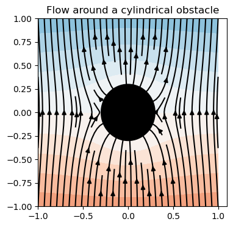

```python
fig, ax = plt.subplots(figsize=(4,4))
Q0 = 1.0                                    # uniform flow
r0 = 0.3                                    # cylinder radius
xmin = -1.; xmax = 1.                       # x-axis plot window
ymin = -1.; ymax = 1.                       # y-axis plot window

x = np.linspace(xmin,xmax,50); y = np.linspace(ymin,ymax,50)
X,Y = np.meshgrid (x,y); Z = X + 1.j*Y      # complex mesh
Phi = Q0*Z + np.conj(Q0*r0*r0/np.conj(Z))   # Uniform horizontal flow is given by Q0*Z

plt.contourf(X,Y,np.imag(Phi),24,cmap='RdBu')
[V,U] = np.gradient(np.imag(Phi))
ax.streamplot(X,Y,U,V,color='k')
circle = plt.Circle((0,0),r0, color='k')
ax.add_patch(circle)
ax.set_title('Flow around a cylindrical obstacle')
plt.show()
```

This flow field has an interpretation in electrostatics. Suppose we insert a long copper cylinder into a uniform electric field perpendicular to its axis. Almost instantly, the free electric charges within the cylinder will settle themselves into an equilibrium distribution such that the electric field becomes steady ("electrostatic"). The figure represents a cross section of this electrostatic field on a plane that cuts perpendicularly through the conductor somewhere in the middle. Just as we require the function to be constant on the boundary of an obstacle in a fluid flow, so we require the real potential to be constant on the boundary of a conductor in an electrostatic field.

In order to allow modelling more complex situations it is convenient to define the $\Omega$ potential in the script in a separate function. The following cell shows how this is done. The input for uniform flow has been changed to simulate diagonal flow.

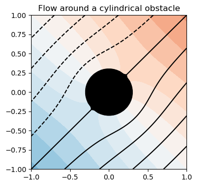

```python
fig, ax = plt.subplots(figsize=(4,4))
def Omega(z):
    global Q0
    omega = np.conj(Q0)*z;
    return omega

Q0 = -0.5*(1+1*1j)                    # baseflow
r0 = .3                               # cylinder radius
xmin = -1.; xmax = 1.                 # x-axis plot window
ymin = -1.; ymax = 1.                 # y-axis plot window

x = np.linspace(xmin,xmax,50)
y = np.linspace(ymin,ymax,50)
X,Y = np.meshgrid (x,y); Z = X + 1.j*Y
Phi = (Omega(Z) + np.conj(Omega(r0*r0/np.conj(Z))))

plt.contourf(X,Y,np.real(Phi),24,cmap='RdBu')
plt.contour (X,Y,np.imag(Phi),24,colors='k')
circle = plt.Circle((0,0),r0, color='k')
ax.add_patch(circle)
ax.set_title('Flow around a cylindrical obstacle')
plt.show()
```

Using the function named 'Omega' we can proceed with more interesting settings. In the following we use superposition adding two logarithm terms. As we know the logarithms represent sinks or sources. For visualization of the streamlines we switch to the 'streamplot' function.

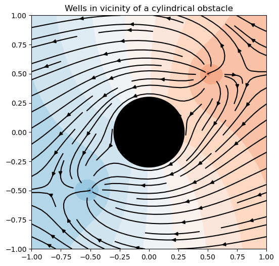

```python
fig, ax = plt.subplots(figsize=(6,6))

def f(z):
    global Qwell,Q0,Gamma,zwell
    omega = np.conj(Q0)*z;
    for k in range (0,len(Qwell)):
        omega = omega + Qwell[k]*np.log(z-zwell[k])/2/np.pi
    return omega

r0 = .3;                                # circle radius
Q0 = -0.5;                              # baseflow
Q = 1;                                  # max pumping rate
Qwell = Q*np.array([1,-1]);             # pumping rate(s)
zwell = 0.5*(1+1j)*np.array([1,-1]);    # well location(s)
xmin = -1.; xmax = 1.;                  # x-axis plot window
ymin = -1.; ymax = 1.;                  # y-axis plot window

x = np.linspace(xmin,xmax,100)
y = np.linspace(ymin,ymax,100)
X,Y = np.meshgrid (x,y); Z = X + 1.j*Y
Phi = (f(Z) + np.conj(f(r0*r0/np.conj(Z))))

plt.contourf(X,Y,np.real(Phi),24,cmap='RdBu')
[V,U] = np.gradient(np.real(Phi))
ax.streamplot(X,Y,U,V,color='k')

circle = plt.Circle((0,0),r0,color='k')
ax.add_patch(circle)
ax.set_title('Wells in vicinity of a cylindrical obstacle')
plt.show()
```

The 'streamplot' function nicely adds direction vectors to the plot. Clearly the sink and source can be identified.

**Task 3**: Add another sink that is half as strong as the others at position $(x,y)$=(-0.75, 0.75)!

### Joukowski Airfoil

#### The Joukowsky Map

A well known example of a conformal function is the *Joukowsky map*

\begin{eqnarray}\label{jouk} w= z+ \lambda^2/z. \end{eqnarray}

It was first used in the study of flow around airplane wings by the pioneering Russian aero and hydrodynamics researcher [Nikolai Zhukovskii](http://mathshistory.st-andrews.ac.uk/Biographies/Zhukovsky.html) (Joukowsky, 1847-1921). Since

$$\frac{d}{dz}w=1-\frac{\lambda^2}{z^2}=0\quad \text{ if and only if }\quad z=\pm \lambda,$$

the function is conformal except at the critical points $z = \pm \lambda$ as well as the singularity $z = 0,$ where it is not defined.

If, for $\lambda$ =1, $z = e^{i\theta}$ lies on the unit circle, then $$w =e^{i\theta}+e^{-i\theta}=2\cos \theta,$$ lies on the real axis, with $-2\leq w\leq 2.$ Thus, the Joukowsky map squashes the unit circle down to the real line segment $[-2, 2].$ The images of points outside the unit circle fill the rest of the $w$ plane, as do the images of the (nonzero) points inside the unit circle. Indeed, if we solve for $z,$ we have $$z=\frac{1}{2}\left(w\pm \sqrt{w^2-4}\right).$$ We see that every $w$ except $\pm 2$ comes from two different points $z$; for $w$ not on the critical line segment $[-2, 2],$ one point (with the minus sign) lies inside and one (with the plus sign) lies outside the unit circle, whereas if $-2 \lt w \lt 2,$ both points lie on the unit circle and a common vertical line.

Therefore, the Joukowski map defines a one-to-one conformal mapping from $| z | \gt; 1,$ the exterior of the unit circle, onto the exterior of the line segment $[-2, 2],$ i. e. $\mathbb C \setminus [-2, 2].$

In the figure below we can observe that the concentric circles $|z|= r \gt 1$ are mapped to ellipses with foci at $\pm 2$ in the $w$-plane. See below the Joukowsky map applied to $|z|=r \geq 1.$

[figure not shown]

The effect on circles not centered at the origin is more interesting. The image curves take in a wide variety of shapes. When the circle passes through the singular point $z=1,$ then its image is no longer smooth, but has a cusp at $w=2$ and when the circle passes through $z=-1$ the cusp is at $w=-2.$ Some of the image curves assume the shape of the famous cross-section through an idealized airplane wing or *airfoil*, also known as the *Joukowsky airfoil*.

You can explore the Joukowsky map in the applet on the web-site [Joukowski Airfoil](https://complex-analysis.com/content/joukowsky_airfoil.html). For arbitrary values of $\lambda $ the critical points are given by $ z = \pm \lambda $.

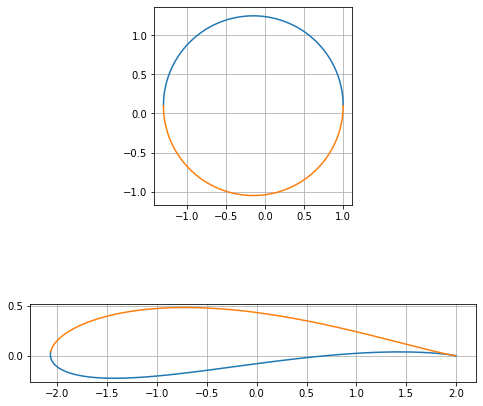

```python
import numpy as np
from matplotlib import pyplot as plt
fig = plt.figure(figsize=(8,8))

# Joukowski transform parameters
lam = 1.0                                # transform parameter
x0, y0 = -0.15, 0.1                      # center of circle in z plane
R = 1.15                                 # circle radius

# curve in z plane
x = np.linspace(-R + x0, R + x0, 1000)
yu = np.sqrt(R**2 - (x - x0)**2) + y0    # upper semi-circle
yl = -np.sqrt(R**2 - (x - x0)**2) + y0   # lower semi-circle
zu = x + 1j* yu   # upper curve
zl = x + 1j* yl   # lower curve

# w plane curve
w_l = zl + lam**2 / zl
w_u = zu + lam**2 / zu

ax1 = fig.add_subplot(211)
ax1.plot(x, yu, x, yl)
ax1.grid()
ax1.set_aspect('equal', adjustable='box')

ax2 = fig.add_subplot(212)
ax2.plot(w_l.real, w_l.imag, w_u.real, w_u.imag)
ax2.grid()
ax2.set_aspect('equal', adjustable='box')
plt.show()
```

#### Flow around the Joukowsky Airfoil

Consider now the uniform flow around the unit circle with circulation $C$ and speed $U \gt;0$ given by the complex potential

\begin{eqnarray}\label{eq1} F(z)=Uz+\frac{U}{z}-\frac{i C}{2\pi}\log z. \end{eqnarray}

We can use the linear transformation

$$T(z)=-0.15+0.23i + 0.23\sqrt{13\cdot 2} z$$

to map this flow around $|z|=1$ onto the flow around the circle $c_1$ with center $z_1=-0.15+0.23i$ and radius $r=0.23\sqrt{13\cdot 2}.$

Finally, by applying the Joukowsky map, one can obtain a uniform flow with circulation around the *Joukowsky airfoil*, check it on [Joukowski Airfoil](https://complex-analysis.com/content/joukowsky_airfoil.html).

### Schwarz-Christoffel Mapping

The Riemann mapping theorem (stated by Bernhard Riemann in his doctorate thesis in 1851) states that for every non-empty, simply connected subset of $\mathbb{C}$ there is a conformal mapping to the unit disk. A domain is called simply connected, if every path between two points can be continuously transformed into any other such path while preserving the two endpoints in question. Intuitively, this corresponds to a space that has no disjoint parts and no holes that go completely through it, because two paths going around different sides of such a hole cannot be continuously transformed into each other.

Riemann's derivation of his theorem was pure theory. For polygonial geometries the Schwarz–Christoffel formula provides an explicit construction. It was derived independently by Elvin Christoffel (1829-1900) and Herrmann Schwarz (1843-1921). The formula says that the complex-variables function $$ f(z)=K\int_{0}^{z} \prod_{k = 1}^{n} (ζ−z_k)^{α_k−1}dζ $$ with a constant $K$ maps the open unit disk 𝔻={𝑧∈ℂ:|𝑧|<1} in the complex plane conformally onto a polygon with $n$ sides, interior angles $0<α_k π<2π$, and vertices $f(z_k)$. The polygon is assumed to be not self-intersecting. The parameters $z_k$ lie on the unit circle, and depend, generally in a complicated way, on the length of the sides of the polygon. The fractional powers $(ζ−z_k)^{α_k−1}$ serve to clamp up an arc of the circle into a pointy angle of measure $α_k π$. The figure below illustrates the procedure.

[figure not shown]

The derivative of $f$ is obviously given by

$$ \frac{df}{dz}=K \prod_{k = 1}^{n} (z−z_k)^{α_k−1} $$

In fact the Riemann mapping theorem show that all simply connected subsets of $\mathbb{C}$ can be transformed into each other with preserving the angles. It can be shown that the Schwarz-Christoffel formula also holds for the transformation from the entire upper half plane of $D=\{z,\text{Im}(z) \ge 0\}$ into the interior of a polygon. Let's as example assume an infinite strip with given $ ζ=z_1$ -- to be at infinity. In this case, the factor $ (ζ-z_1)$ in the equation becomes effectively constant, and can be absorbed into the constant $ K$.

$$ f(z)=\int_{0}^{z} \frac{K}{(ζ−z_2)^{α_2−1}ζ−z_3)^{α_3−1}}dζ $$

A strip in the complex plane can be represented by a triangle with two right angles and one point in infinity. Lets assume $z_2=1$ and $z_3=-1$. The formula then becomes

$$ f(z)=\int_{0}^{z} \frac{K}{(ζ−1)^{1/2}(ζ+1)^{1/2}}dζ $$

or $$ f(z)=\int_{0}^{z} \frac{K}{(ζ^2−1)^{1/2}}dζ $$

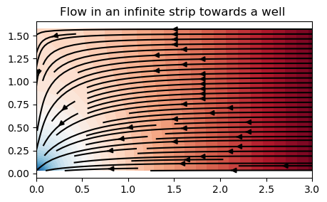

```python
Q  = 1                                      # pumping rate
xmin = 0.; xmax = 3.                        # x-axis plot window
ymin = 0.03; ymax = np.pi/2                 # y-axis plot window

x = np.linspace(xmin,xmax,50); y = np.linspace(ymin,ymax,50)
X,Y = np.meshgrid (x,y); Z = X + 1.j*Y      # complex mesh
Z = np.cosh(Z-1j*np.pi/2)
Phi = -Q*np.log(Z)/2/np.pi
fig, ax = plt.subplots(figsize=(5,7))
plt.contourf(X,Y,np.real(Phi),48,cmap='RdBu')
[V,U] = np.gradient(np.real(Phi))
ax.streamplot(X,Y,U,V,color='k')
ax.set_aspect('equal')
ax.set_title('Flow in an infinite strip towards a well ')
plt.show()
```

**Task 4**: Explore the relation between the thickness of the strip and the constant in the cosh-function!